# Project 1 alt

Rene Bergeron, Joseph Mukanda, Aiyanah Kasota

2025/11/09

# Initialize

Load libraries:

```r
library(car)
library(dplyr)
library(caret)
```

```r
library(ggplot2)
library(rpart)
library(rpart.plot)
library(mclust)
library(rsample)
library(pROC)
```

# 1. Load Data

In this section, we will load the dataset required for the analysis.

```r
CarTrain <- read.csv('car_train_class_wi_29.csv',
                     header = TRUE)
```

*Interpretation*: The CarTrain dataset we just loaded includes vehicle information including (but not limited to) technical specifications, physical characteristics, accident history, listing history, where the vehicle was sourced, and our variable of interest Price. The price is not a number, it is whether or not the vehicle was priced high or if it was priced low.

# 2. Explore Data

Explore the data to understand its structure, summary statistics, and any potential issues with missing values or outliers.

## EDA1

```r
str(CarTrain)
```

```
## 'data.frame':    10719 obs. of  58 variables:
##  $ X                   : int  1 2 3 4 5 6 7 8 9 10 ...
##  $ vin                 : chr  "5J8YD3H53LL006775" "1C4RJFJT9LC402084" "2HGFC2F53JH537301" "3FA6P0HD7LR262542" ...
##  $ back_legroom        : num  36.6 38.6 37.4 38.3 38.4 41.7 37.9 43.6 43.6 39 ...
##  $ body_type           : chr  "SUV / Crossover" "SUV / Crossover" "Sedan" "Sedan" ...
##  $ cabin               : chr  "" "" "" "" ...
##  $ city                : chr  "Roswell" "Silver Spring" "Tupelo" "Snellville" ...
##  $ daysonmarket        : int  100 39 134 61 5 68 23 55 48 34 ...
##  $ dealer_zip          : chr  "30076" "20904" "38801" "30039" ...
##  $ engine_cylinders    : chr  "V6" "V8" "I4" "I4" ...
##  $ engine_displacement : int  3500 5700 2000 2500 3500 3500 2500 5000 5000 3600 ...
##  $ engine_type         : chr  "V6" "V8" "I4" "I4" ...
##  $ exterior_color      : chr  "Lunar Silver Metallic" "Billet Silver Metallic Clear-Coat Exterior Paint" "Gray" "Red Metallic" ...
##  $ fleet               : chr  "False" "" "True" "False" ...
##  $ frame_damaged       : chr  "False" "" "False" "False" ...
```

[output cut: 44 more lines]

```r
str(CarTrain$horsepower)
```

```
##  int [1:10719] 290 360 158 175 280 260 170 395 395 310 ...
```

```r
summary(CarTrain$horsepower)
```

```
##    Min. 1st Qu.  Median    Mean 3rd Qu.    Max.
##   101.0   177.0   248.0   250.7   301.5   760.0
```

```r
str(CarTrain$power_hp)
```

```
##  int [1:10719] 290 360 158 181 280 260 170 395 395 310 ...
```

```r
summary(CarTrain$power_hp)
```

```
##    Min. 1st Qu.  Median    Mean 3rd Qu.    Max.
##   101.0   180.0   250.0   252.3   305.0   760.0
```

The two power columns have different summary stats, that means there must be differences between the two. Lets check deeper so we ensure we use the best column based on data accuracy.

```r
power_hpC <- CarTrain %>%
  select(power_hp,
         vin)

horsepowerC <- CarTrain %>%
  select(horsepower,
         vin)
```

```r
ComparisonDF <- full_join(x= power_hpC,
                           y= horsepowerC)
ComparisonDF$difference <- ComparisonDF$power_hp - ComparisonDF$horsepower

summary(ComparisonDF$difference)
```

```
##     Min.  1st Qu.   Median     Mean  3rd Qu.     Max.
## -155.000    0.000    0.000    1.656    0.000  155.000
```

We see that the resulting dataframe confirms a difference between the two dataframe. On average the two columns ‘power_hp’ and ‘horsepower’ are different by 1.656. We added a column that creates a difference between the two columns. If the difference of the values is 0, then the two values are equivalent. There are:

```r
sum(!near(ComparisonDF$difference,0))
```

```
## [1] 1292
```

rows that do not have the same value for ‘power_hp’ and ‘horsepower’ (see preprocessing Step 1 for continuation) we can for sure say that vehicles with over 600 horsepower are priced HIGH.

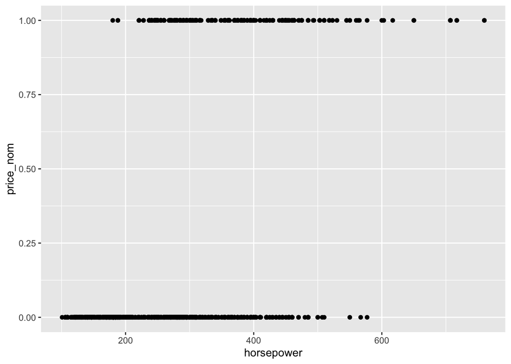

```r
EDA1 <- ggplot(data = CarTrain,
               aes(
                 x = horsepower,
                 y = price_nom)) +
  geom_point()

EDA1
```

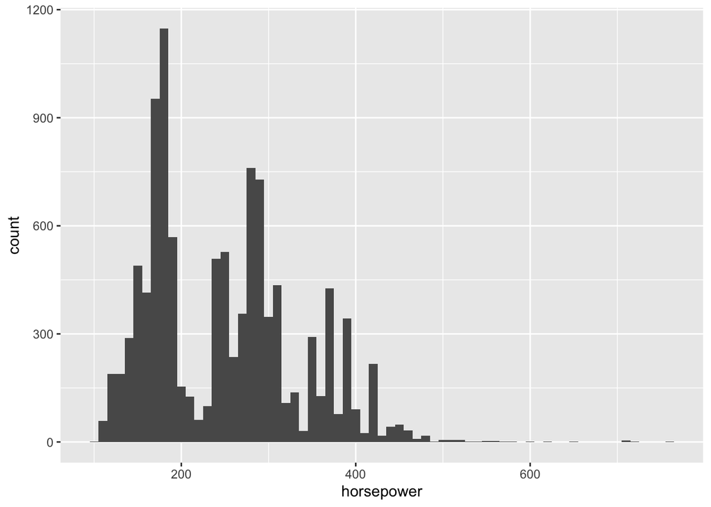

```r
horsepowerEDA <- ggplot(data = CarTrain,
                        aes(x= horsepower
                        )) +
  geom_histogram(binwidth = 10)
horsepowerEDA
```

There are two semi-normalized groupings in the horsepower variable, and a third grouping that is skewed. It looks like around 110-230 horsepower, and 240-350 are normally distributed, and 350-500 is skewed with a tail to the right. The algorithms should handle grouping these if needed.

## EDA2

-Suggests a relationship between vehicles newer than 2010 being listed high.

```r
summary(CarTrain$year)
```

```
##    Min. 1st Qu.  Median    Mean 3rd Qu.    Max.
##    1991    2017    2019    2018    2020    2021
```

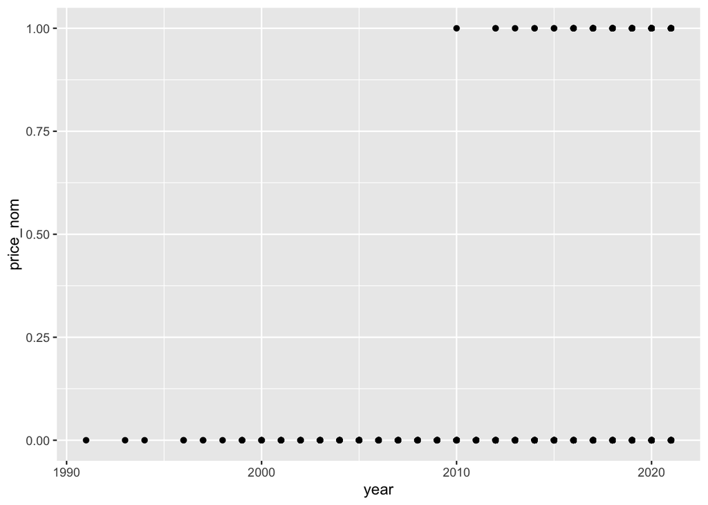

```r
EDA2 <- ggplot(data = CarTrain,
               aes(
                 x = year,
                 y = price_nom)) +
  geom_point()
EDA2
```

```r
str(CarTrain$year)
```

```
##  int [1:10719] 2020 2020 2018 2020 2021 2016 2017 2018 2018 2020 ...
```

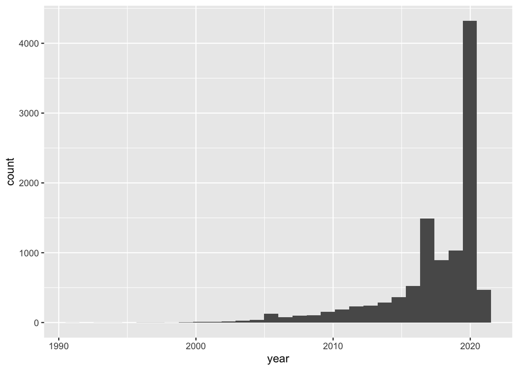

```r
yearEDA <- ggplot(data = CarTrain,
                  aes(
                    x= year
                  )) +
  geom_histogram()
yearEDA
```

There are defintely some outliers in the data, lets run the IQR test. This is a test and tool used to take the “middle average data range” to determine what values are extreme. For example there are vehicles as old as 1991 in the data. The “middle average data range” (IQR) of this data is 2017 to 2020 though. The vehicle that is from 1991 is considered an extreme value and skews the data which affects the models ability to predict the average vehicle you would be trying to sell. If we remove outliers, we do narrow the effective scope of this model. This model has specific parameters that will be explained in the limitations section at the end.

```r
print(
  quantile(CarTrain$year,
           0.25) -
    (1.5 * IQR(CarTrain$year))
)
```

```
##    25%
## 2012.5
```

Anything below that number is considered an outlier. As long as we do not lose excessive amounts of data, we may remove them for clarity and accuracy.

```r
CarTrain1 <- CarTrain %>%
  filter(year > quantile(CarTrain$year,
           0.25) -
    (1.5 * IQR(CarTrain$year)))
```

Let’s see how much data we removed.

```r
yearDataLoss <- 100* (nrow(CarTrain) - nrow(CarTrain1)) / nrow(CarTrain)
yearDataLoss
```

```
## [1] 10.1502
```

We would be losing that 10.15% portion of the data, which is unacceptable (too much). This, as the histogram suggests that the year is skewed with less cars in a wider range from 1991-2012 (the lower limit for outliers). We will keep without modifying our dataset and keeping the mathematical outliers.

## EDA3

-Shows that the following colors seem to be listed NOT high: (purple, teal, yellow).

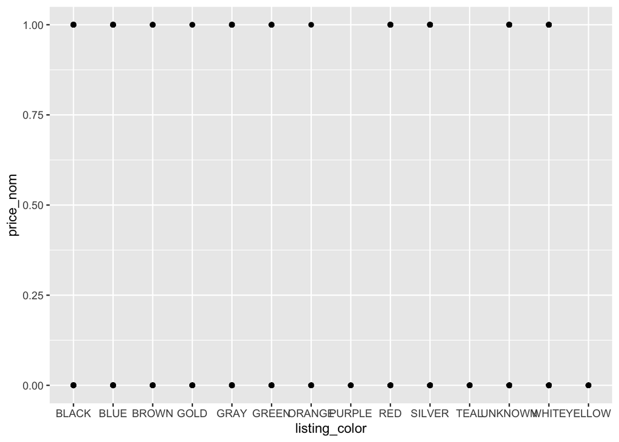

```r
EDA3 <- ggplot(data = CarTrain,
               aes(
                 x = listing_color,
                 y = price_nom)) +
  geom_point()
EDA3
```

```r
str(CarTrain$listing_color)
```

```
##  chr [1:10719] "SILVER" "SILVER" "GRAY" "RED" "SILVER" "BROWN" "BLACK" ...
```

```r
CarTrain$listing_color <- as.factor(CarTrain$listing_color)

str(CarTrain$listing_color)
```

```
##  Factor w/ 14 levels "BLACK","BLUE",..: 10 10 5 9 10 3 1 1 2 12 ...
```

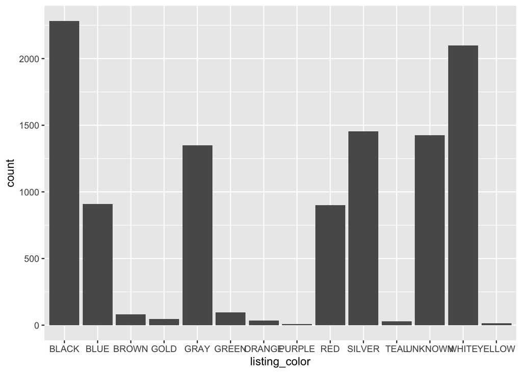

```r
colorEDA <- ggplot(data = CarTrain,
                   aes(
                     x= listing_color
                   )) +
  geom_bar()

colorEDA
```

```r
summary(CarTrain$listing_color)
```

```
##   BLACK    BLUE   BROWN    GOLD    GRAY   GREEN  ORANGE  PURPLE     RED  SILVER
##    2283     908      80      45    1348      95      36       8     899    1453
##    TEAL UNKNOWN   WHITE  YELLOW
##      28    1424    2098      14
```

Note the statistical reliability is questionable for the following colors due to insufficient data: purple, teal, yellow

## EDA4

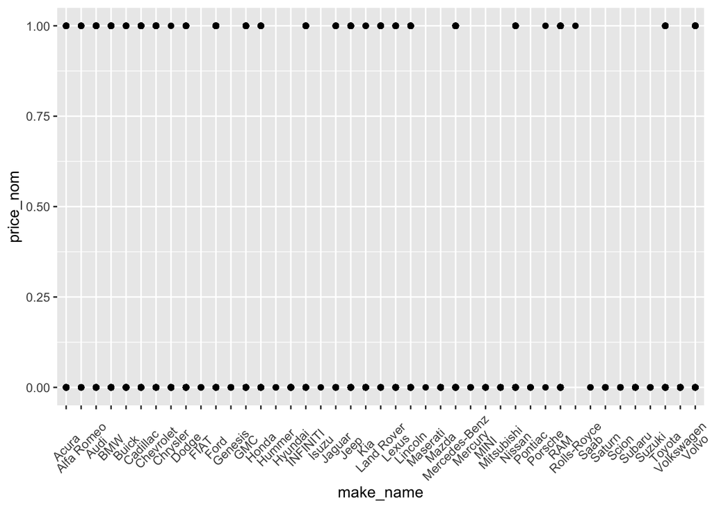

```r
EDA4 <- ggplot(data = CarTrain,
               aes(
                 x = make_name,
                 y = price_nom)) +
  geom_point() +
  theme(
    axis.text.x = element_text(
      angle = 45,
      hjust = .5,
      vjust = .5
    )
  )
EDA4
```

```r
str(CarTrain$make_name)
```

```
##  chr [1:10719] "Acura" "Jeep" "Honda" "Ford" "Honda" "Nissan" "Nissan" ...
```

```r
CarTrain$make_name <- as.factor(CarTrain$make_name)

str(CarTrain$make_name)
```

```
##  Factor w/ 43 levels "Acura","Alfa Romeo",..: 1 20 14 11 14 31 31 11 11 6 ...
```

```r
summary(CarTrain$make_name)
```

```
##         Acura    Alfa Romeo          Audi           BMW         Buick
##           135            16           153           219           188
##      Cadillac     Chevrolet      Chrysler         Dodge          FIAT
##           189          1285           157           384             6
##          Ford       Genesis           GMC         Honda        Hummer
##          1395             8           395           937             3
##       Hyundai      INFINITI         Isuzu        Jaguar          Jeep
##           517           115             1            34           739
##           Kia    Land Rover         Lexus       Lincoln      Maserati
##           413            66           123           147             1
##         Mazda Mercedes-Benz       Mercury          MINI    Mitsubishi
##           214           256             7            33            34
##        Nissan       Pontiac       Porsche           RAM   Rolls-Royce
##           933            11             2           334             1
##          Saab        Saturn         Scion        Subaru        Suzuki
##             2             8             6           325             6
##        Toyota    Volkswagen         Volvo
##           576           239           106
```

Similar issues as above, we may not have enough data to be sure about several of these makes. We DO NOT have enough data for the following makes: Alpha Romeo, Fiat, Genesis, Hummer, Isuzu, Maserati, Mercury, Pontiac, Porsche, Rolls-Royce, Saab, Saturn, Scion, Suzuki

In addition to the above listed makes, when we train the model, we have to split the data. We do not have enough data for the following makes to be reliable after the (70/30) split: Jaguar, Mitsubishi

## EDA5

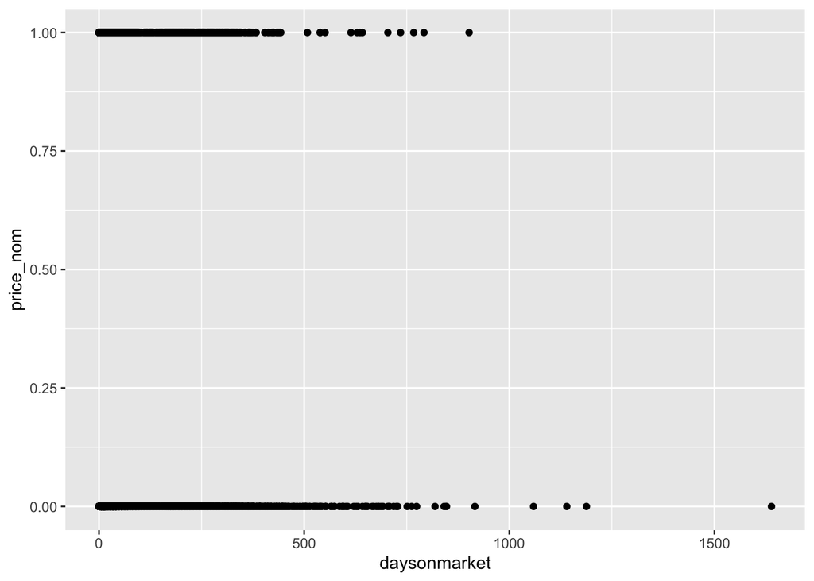

```r
EDA5 <- ggplot(data = CarTrain,
               aes(
                 x = daysonmarket,
                 y = price_nom)) +
  geom_point()
EDA5
```

Further analyses will look at potential outliers.

```r
uFence_daysonmarket <- quantile(CarTrain$daysonmarket,
           0.25) +
    (1.5 * IQR(CarTrain$daysonmarket))
```

So the upper limit would be 108.5 days. Let’s see how much data would be lost if we remove outliers.

```r
CarTrain1 <- CarTrain %>%
  filter(daysonmarket < quantile(CarTrain$daysonmarket,
           0.25) +
    (1.5 * IQR(CarTrain$daysonmarket)))

DataLoss <- 100 * (nrow(CarTrain)-nrow(CarTrain1))/nrow(CarTrain)

str(CarTrain1)
```

```
## 'data.frame':    8680 obs. of  58 variables:
##  $ X                   : int  1 2 4 5 6 7 8 9 10 11 ...
##  $ vin                 : chr  "5J8YD3H53LL006775" "1C4RJFJT9LC402084" "3FA6P0HD7LR262542" "5FNYF6H24MB010760" ...
##  $ back_legroom        : num  36.6 38.6 38.3 38.4 41.7 37.9 43.6 43.6 39 43.6 ...
##  $ body_type           : chr  "SUV / Crossover" "SUV / Crossover" "Sedan" "SUV / Crossover" ...
##  $ cabin               : chr  "" "" "" "" ...
##  $ city                : chr  "Roswell" "Silver Spring" "Snellville" "Michigan City" ...
##  $ daysonmarket        : int  100 39 61 5 68 23 55 48 34 12 ...
##  $ dealer_zip          : chr  "30076" "20904" "30039" "46360" ...
##  $ engine_cylinders    : chr  "V6" "V8" "I4" "V6" ...
##  $ engine_displacement : int  3500 5700 2500 3500 3500 2500 5000 5000 3600 6200 ...
##  $ engine_type         : chr  "V6" "V8" "I4" "V6" ...
##  $ exterior_color      : chr  "Lunar Silver Metallic" "Billet Silver Metallic Clear-Coat Exterior Paint" "Red Metallic" "lunar silver metallic" ...
##  $ fleet               : chr  "False" "" "False" "" ...
##  $ frame_damaged       : chr  "False" "" "False" "" ...
```

[output cut: 44 more lines]

```r
print(DataLoss)
```

```
## [1] 19.0223
```

Again, if we were to remove outliers, we would be removing too much data (19%). We will continue without removing any outliers for daysonmarket. Let’s explore the data that would be removed for patterns

```r
daysOutliers <- CarTrain %>%
  filter(daysonmarket > quantile(CarTrain$daysonmarket,
           0.25) +
    (1.5 * IQR(CarTrain$daysonmarket)))
```

There would be 2039 outliers removed above the upper fence. That would be unacceptable, but maybe those extreme values have a pattern

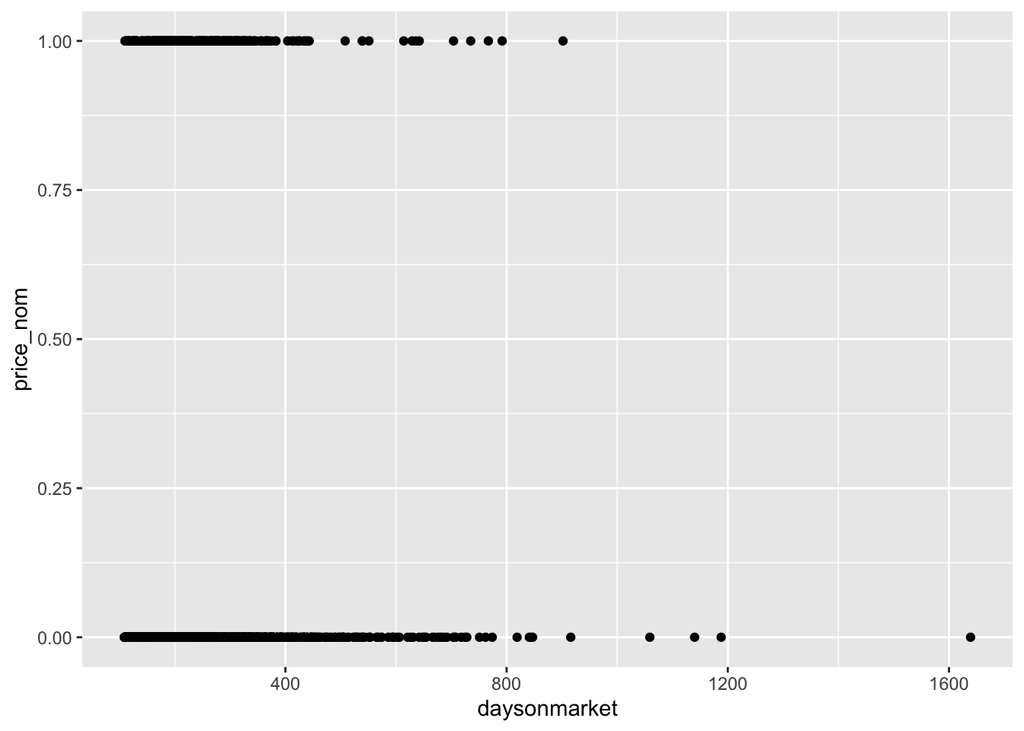

```r
daysOutplot <- ggplot(data =  daysOutliers,
                     aes(
                       x= daysonmarket,
                       y= price_nom
                     )) +
  geom_point()
daysOutplot
```

There is no obvious pattern. Continuing with the original dataframe

```r
rm(
  daysOutliers,
  daysOutplot,
  CarTrain1,
  DataLoss,
  uFence_daysonmarket,
  yearDataLoss
)
```

## EDA6

-Shows that damaged frames are listed NOT high.

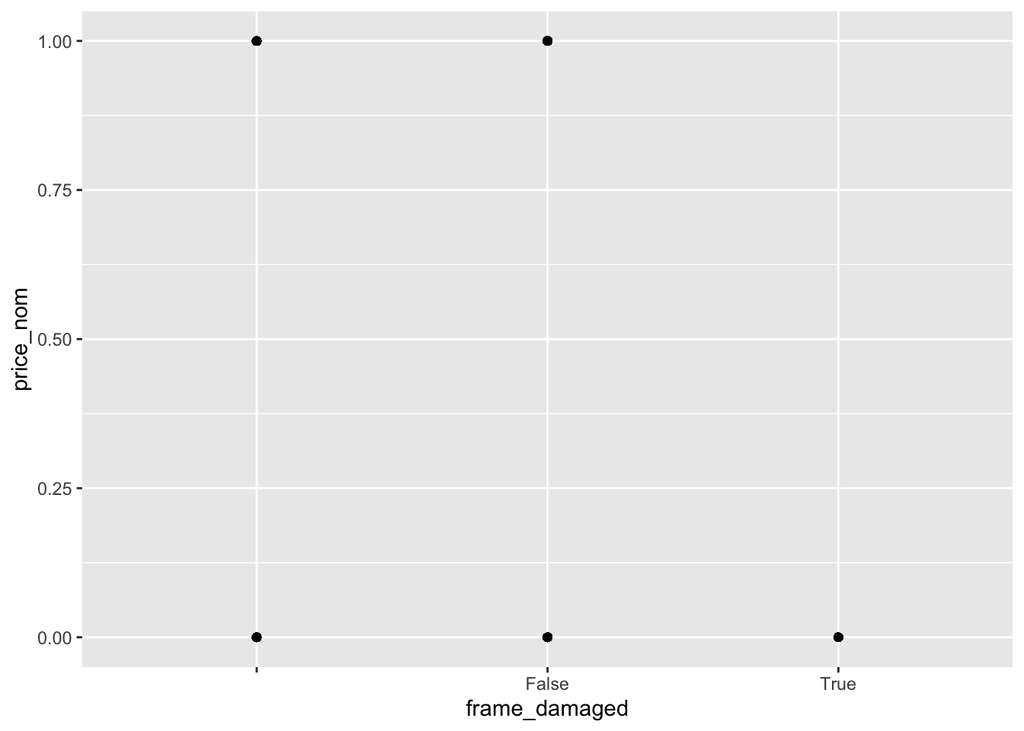

```r
EDA6 <- ggplot(data =  CarTrain,
               aes(
                 x= frame_damaged,
                 y= price_nom)) +
  geom_point()
EDA6
```

```r
str(CarTrain$frame_damaged)
```

```
##  chr [1:10719] "False" "" "False" "False" "" "False" "False" "False" ...
```

```r
CarTrain$frame_damaged <- as.factor(CarTrain$frame_damaged)
str(CarTrain$frame_damaged)
```

```
##  Factor w/ 3 levels "","False","True": 2 1 2 2 1 2 2 2 2 1 ...
```

```r
summary(CarTrain$frame_damaged)
```

```
##       False  True
##  4421  6241    57
```

We see that there are 4421 missing responses. considering frame damage is extremely uncommon and the next option would be using a statistics tool called multiple imputation that I do not understand how to implement. I recommend creating a new category ‘unkown’ for the missing values. See preprocessing STEP 6. for the creation.

## EDA7

-Shows that certain engines are listed NOT high: (H4, H6, I3, I4 flex fuel, I4 hybrid, I5, V10, W12), on the contrary, V12s and V6 hybrid engines are listed high.

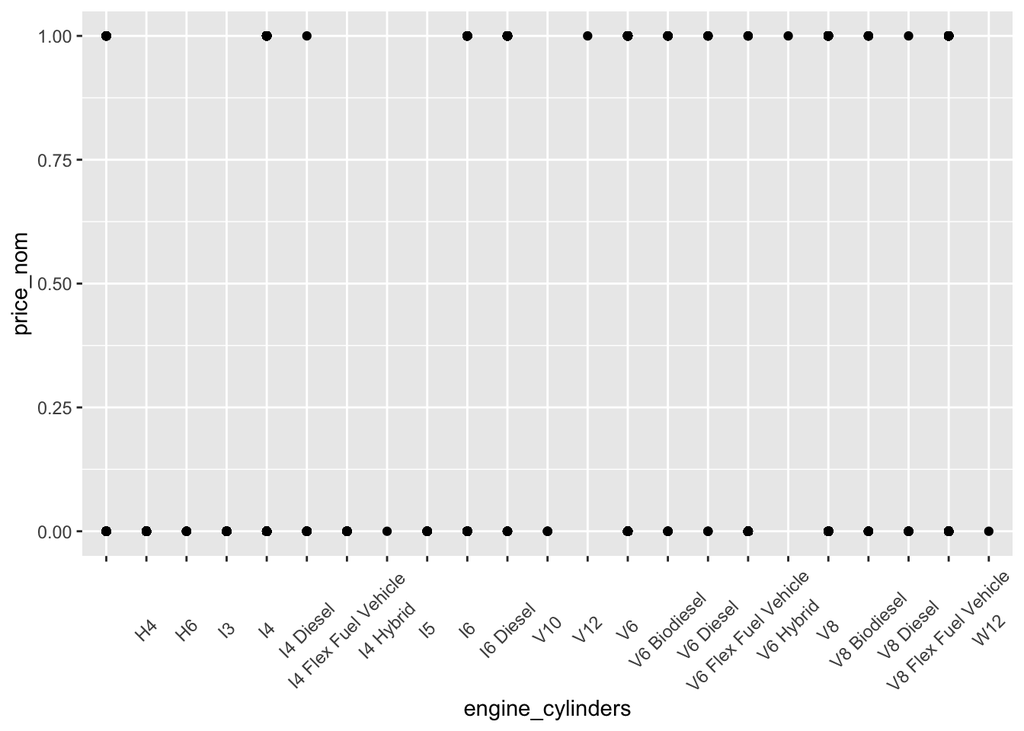

```r
EDA7 <- ggplot(data = CarTrain,
               aes(
                 x = engine_cylinders,
                 y = price_nom)) +
  geom_point() +
  theme(
    axis.text.x = element_text(
      angle = 45,
      hjust = .5,
      vjust = .5
    )
  )
EDA7
```

```r
str(CarTrain$engine_cylinders)
```

```
##  chr [1:10719] "V6" "V8" "I4" "I4" "V6" "V6" "I4" "V8" "V8" "V6" ...
```

```r
CarTrain$engine_cylinders <- as.factor(CarTrain$engine_cylinders)
str(CarTrain$engine_cylinders)
```

```
##  Factor w/ 23 levels "","H4","H6","I3",..: 14 19 5 5 14 14 5 19 19 14 ...
```

```r
summary(CarTrain$engine_cylinders)
```

```
##                                        H4                   H6
##                  118                  317                    8
##                   I3                   I4            I4 Diesel
##                  103                 5194                   33
## I4 Flex Fuel Vehicle            I4 Hybrid                   I5
##                   44                    1                   22
##                   I6            I6 Diesel                  V10
##                  106                   85                    4
##                  V12                   V6         V6 Biodiesel
##                    1                 3046                   19
##            V6 Diesel V6 Flex Fuel Vehicle            V6 Hybrid
##                    7                  251                    1
##                   V8         V8 Biodiesel            V8 Diesel
##                 1066                   19                   12
## V8 Flex Fuel Vehicle                  W12
##                  261                    1
```

As above, let’s discuss whether we have enough data to support claims about correlation to sales: We DO NOT have enough data for the following engines: H6, I4 Hybrid, I5, V10, V12, V6 Biodiesel, V6 Diesel, V6 Hybrid, V8 Biodiesel, V8 Diesel, W12. See STEP 7 in preprocessing for handling of these.

## EDA8

-Shows that anything less than (just over) 160 length is listed NOT high.

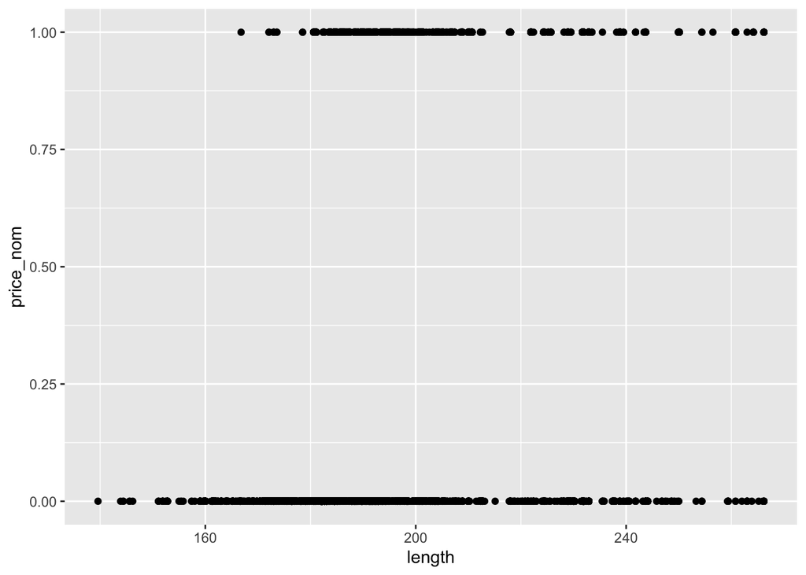

```r
EDA8<- ggplot(data = CarTrain,
               aes(
                 x = length,
                 y = price_nom)) +
  geom_point()
EDA8
```

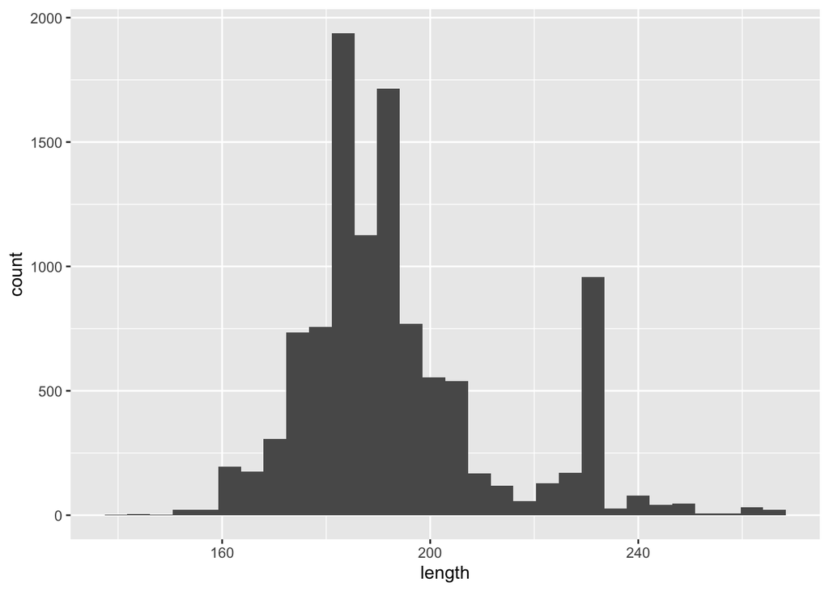

```r
lengthEDA <- ggplot(data =  CarTrain,
                    aes(
                      x= length
                    )) +
  geom_histogram()

lengthEDA
```

We again see a normal distribution of data between around 160 - 220, and potentially a second distribution between 220 -260. This tells me there are likely two categories of vehicles for lengths. The second distribution may be commercial vehicles. We may do more preprocessing to confirm, or at least bean these into classes that will be more useful than continuous variables. See STEP 8 for preprocessing

## EDA9

—–Shows that dual clutch transmissions do not list high.

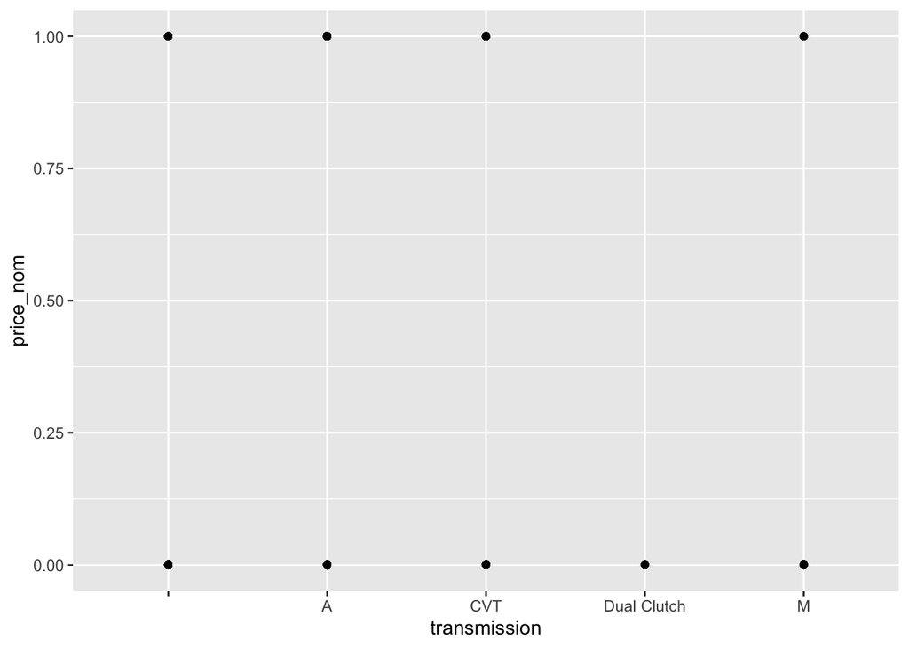

```r
EDA9 <- ggplot(data = CarTrain,
               aes(
                 x = transmission,
                 y = price_nom)) +
  geom_point()
EDA9
```

```r
str(CarTrain$transmission)
```

```
##  chr [1:10719] "A" "A" "CVT" "A" "A" "A" "A" "A" "" "A" "A" "CVT" "A" "A" ...
```

```r
CarTrain$transmission <- as.factor(CarTrain$transmission)
str(CarTrain)
```

```
## 'data.frame':    10719 obs. of  58 variables:
##  $ X                   : int  1 2 3 4 5 6 7 8 9 10 ...
##  $ vin                 : chr  "5J8YD3H53LL006775" "1C4RJFJT9LC402084" "2HGFC2F53JH537301" "3FA6P0HD7LR262542" ...
##  $ back_legroom        : num  36.6 38.6 37.4 38.3 38.4 41.7 37.9 43.6 43.6 39 ...
##  $ body_type           : chr  "SUV / Crossover" "SUV / Crossover" "Sedan" "Sedan" ...
##  $ cabin               : chr  "" "" "" "" ...
##  $ city                : chr  "Roswell" "Silver Spring" "Tupelo" "Snellville" ...
##  $ daysonmarket        : int  100 39 134 61 5 68 23 55 48 34 ...
##  $ dealer_zip          : chr  "30076" "20904" "38801" "30039" ...
##  $ engine_cylinders    : Factor w/ 23 levels "","H4","H6","I3",..: 14 19 5 5 14 14 5 19 19 14 ...
##  $ engine_displacement : int  3500 5700 2000 2500 3500 3500 2500 5000 5000 3600 ...
##  $ engine_type         : chr  "V6" "V8" "I4" "I4" ...
##  $ exterior_color      : chr  "Lunar Silver Metallic" "Billet Silver Metallic Clear-Coat Exterior Paint" "Gray" "Red Metallic" ...
##  $ fleet               : chr  "False" "" "True" "False" ...
##  $ frame_damaged       : Factor w/ 3 levels "","False","True": 2 1 2 2 1 2 2 2 2 1 ...
```

[output cut: 44 more lines]

```r
summary(CarTrain$transmission)
```

```
##                       A         CVT Dual Clutch           M
##         158        8726        1656          25         154
```

Again we run into the issue of data. We DO NOT have enough data to support claims regarding dual clutch transmissions. See STEP 9 preprocessing for how this was handled.

### Finally, let’s ensure the overall integrity of data and list out the values that need cleaning for our variables of interest.

```r
CarTrainCondensed <- CarTrain %>%
  select(vin,
         horsepower,
         power_hp,
         year,
         listing_color,
         make_name,
         daysonmarket,
         frame_damaged,
         engine_cylinders,
         length,
         transmission,
         price_nom)
```

# 3. Data Preprocessing

```r
powerDF <- ComparisonDF %>%
  filter(!near(difference,0))
```

The resulting dataframe shows 1292 observations where the horsepower does not match the power_hp Checking a handful one by one, it seems there are errors in the ‘power_hp’ column. The first vin I checked is ‘1B4GP44G1YB680822’ and is listed online technically as 158 horsepower (horsepower) column. The next random VIN I selected is ‘1C6RRFFG8LN377095’ listed also online as having 305 horsepower (horsepower column). Lets do a random 3rd one to see ‘1GC4YUE78LF123604’ is listed online as 401 horsepower (power_hp column) This leads to an interesting dillemma. It seems that neither column is more accurate to their listings. The best option which may be beyond my abilities right now would be to verify all this information online through the VIN. I do not know any code to do this, and it would too time consuming to perform by hand. I will create a 3rd column to average the two together. The ‘powerAVG’ column will be used going forward. Depending on the source of this data, we could choose better which column to use in our data. For example, regardless what caused the discrepancies in the power columns, the decision of the consumer whether to purchase the vehicle at the asking price may be influenced by the power of the vehicle, but they can only make that decision based on the horsepower rating that they see.

```r
CarTrainCondensed <- CarTrain %>%
  select(vin,
         power_hp,
         horsepower,
         year,
         listing_color,
         make_name,
         daysonmarket,
         frame_damaged,
         engine_cylinders,
         length,
         transmission,
         wheel_system,
         price_nom)



CarTrainCondensed$powerAVG <- ( CarTrainCondensed$power_hp + CarTrainCondensed$horsepower ) /2
```

The ‘powerAVG’ column will be used going forward.

```r
CarTrainCondensed <- CarTrainCondensed %>%
  select(vin,
         powerAVG,
         year,
         listing_color,
         make_name,
         daysonmarket,
         frame_damaged,
         engine_cylinders,
         length,
         transmission,
         price_nom)
rm(
  ComparisonDF,
  difference,
  horsepowerC,
  power_hpC
)
```

Checking powerAVG

```r
str(CarTrainCondensed$powerAVG)
```

```
##  num [1:10719] 290 360 158 178 280 260 170 395 395 310 ...
```

```r
sum(is.na(CarTrainCondensed$powerAVG))
```

```
## [1] 0
```

```r
sum(CarTrainCondensed$powerAVG == "")
```

```
## [1] 0
```

```r
sum(CarTrainCondensed$powerAVG == 0)
```

```
## [1] 0
```

## Step 2 ‘year’

Checking for any cleaning to the year.

```r
str(CarTrainCondensed$year)
```

```
##  int [1:10719] 2020 2020 2018 2020 2021 2016 2017 2018 2018 2020 ...
```

```r
summary(CarTrainCondensed$year)
```

```
##    Min. 1st Qu.  Median    Mean 3rd Qu.    Max.
##    1991    2017    2019    2018    2020    2021
```

```r
sum(is.na(CarTrainCondensed$year))
```

```
## [1] 0
```

```r
sum(CarTrainCondensed$year == "")
```

```
## [1] 0
```

```r
sum(CarTrainCondensed$year == 0)
```

```
## [1] 0
```

No actions taken, the column is fine.

## Step 3 ‘listing_color’

Checking ‘listing_color’

```r
summary(CarTrainCondensed$listing_color)
```

```
##   BLACK    BLUE   BROWN    GOLD    GRAY   GREEN  ORANGE  PURPLE     RED  SILVER
##    2283     908      80      45    1348      95      36       8     899    1453
##    TEAL UNKNOWN   WHITE  YELLOW
##      28    1424    2098      14
```

```r
sum(is.na(CarTrainCondensed$listing_color))
```

```
## [1] 0
```

```r
sum(CarTrainCondensed$listing_color == "")
```

```
## [1] 0
```

```r
sum(CarTrainCondensed$listing_color == 0)
```

```
## [1] 0
```

## Step 4 ‘make_name’

Checking make_name

```r
summary(CarTrainCondensed$make_name)
```

```
##         Acura    Alfa Romeo          Audi           BMW         Buick
##           135            16           153           219           188
##      Cadillac     Chevrolet      Chrysler         Dodge          FIAT
##           189          1285           157           384             6
##          Ford       Genesis           GMC         Honda        Hummer
##          1395             8           395           937             3
##       Hyundai      INFINITI         Isuzu        Jaguar          Jeep
##           517           115             1            34           739
##           Kia    Land Rover         Lexus       Lincoln      Maserati
##           413            66           123           147             1
##         Mazda Mercedes-Benz       Mercury          MINI    Mitsubishi
##           214           256             7            33            34
##        Nissan       Pontiac       Porsche           RAM   Rolls-Royce
##           933            11             2           334             1
##          Saab        Saturn         Scion        Subaru        Suzuki
##             2             8             6           325             6
##        Toyota    Volkswagen         Volvo
##           576           239           106
```

```r
sum(is.na(CarTrainCondensed$make_name))
```

```
## [1] 0
```

```r
sum(CarTrainCondensed$make_name == "")
```

```
## [1] 0
```

## Step 5 ‘daysonmarket’

Checking daysonmarket

```r
str(CarTrainCondensed$daysonmarket)
```

```
##  int [1:10719] 100 39 134 61 5 68 23 55 48 34 ...
```

```r
summary(CarTrainCondensed$daysonmarket)
```

```
##    Min. 1st Qu.  Median    Mean 3rd Qu.    Max.
##    0.00   14.00   35.00   73.04   77.00 1639.00
```

```r
sum(is.na(CarTrainCondensed$daysonmarket))
```

```
## [1] 0
```

```r
sum(CarTrainCondensed$daysonmarket == "")
```

```
## [1] 0
```

```r
sum(CarTrainCondensed$daysonmarket == 0)
```

```
## [1] 158
```

## Step 6 ‘frame_damaged’

Checking frame_damaged

```r
str(CarTrain$frame_damaged)
```

```
##  Factor w/ 3 levels "","False","True": 2 1 2 2 1 2 2 2 2 1 ...
```

```r
summary(CarTrainCondensed$frame_damaged)
```

```
##       False  True
##  4421  6241    57
```

```r
sum(is.na(CarTrainCondensed$frame_damaged)) #not seeing them as NA
```

```
## [1] 0
```

```r
sum(CarTrainCondensed$frame_damaged == "") #there it is, they are recognized as blank
```

```
## [1] 4421
```

```r
CarTrainCondensed$frame_damaged <- (CarTrainCondensed$frame_damaged)
CarTrainCondensed$frame_damaged[CarTrainCondensed$frame_damaged == "" ] <- NA

str(CarTrainCondensed$frame_damaged)
```

```
##  Factor w/ 3 levels "","False","True": 2 NA 2 2 NA 2 2 2 2 NA ...
```

```r
levels(CarTrainCondensed$frame_damaged) <- c(levels(CarTrainCondensed$frame_damaged), "UNK")

CarTrainCondensed$frame_damaged[is.na(CarTrainCondensed$frame_damaged)] <- "UNK"

str(CarTrainCondensed$frame_damaged)
```

```
##  Factor w/ 4 levels "","False","True",..: 2 4 2 2 4 2 2 2 2 4 ...
```

We have 4421 observations missing a True or False. We created a new level to the categorical variable of ‘frame_damaged.’ It used to only have the options of True or False for, but now the value can be either True, False, or UNK. UNK indicates the value was missing in the original data.

## Step 7 ‘engine_cylinders’

Checking Engines

```r
str(CarTrainCondensed$engine_cylinders)
```

```
##  Factor w/ 23 levels "","H4","H6","I3",..: 14 19 5 5 14 14 5 19 19 14 ...
```

```r
summary(CarTrainCondensed$engine_cylinders)
```

```
##                                        H4                   H6
##                  118                  317                    8
##                   I3                   I4            I4 Diesel
##                  103                 5194                   33
## I4 Flex Fuel Vehicle            I4 Hybrid                   I5
##                   44                    1                   22
##                   I6            I6 Diesel                  V10
##                  106                   85                    4
##                  V12                   V6         V6 Biodiesel
##                    1                 3046                   19
##            V6 Diesel V6 Flex Fuel Vehicle            V6 Hybrid
##                    7                  251                    1
##                   V8         V8 Biodiesel            V8 Diesel
##                 1066                   19                   12
## V8 Flex Fuel Vehicle                  W12
##                  261                    1
```

```r
sum(is.na(CarTrainCondensed$engine_cylinders))
```

```
## [1] 0
```

```r
sum(CarTrainCondensed$engine_cylinders == "")
```

```
## [1] 118
```

118 values are missing in the ‘engine_cylinders’ column.

Let’s see those observations in isolation

```r
MissingEngineValues <- CarTrain %>%
  filter(engine_cylinders == "")
head(MissingEngineValues)
```

```
##     X               vin back_legroom       body_type cabin        city
## 1 417 1GB3KYCG3GZ349162         40.9    Pickup Truck         Hollywood
## 2 450 KL4MMDSL0LB107976         36.0 SUV / Crossover        Villa Park
## 3 580 1GCVKREC6GZ152734         34.6    Pickup Truck       Bloomington
## 4 607 1FT7W2BT1KEF92515         43.6    Pickup Truck            Forest
## 5 622 1GKKNSLS6JZ208694         39.7 SUV / Crossover       Center Line
## 6 741 3N1AB7AP8KY410267         37.4           Sedan        Greenville
##   daysonmarket dealer_zip engine_cylinders engine_displacement engine_type
## 1           63      33023                                 6600
## 2          146      60181                                 1300
## 3           22      55431                                 5300
## 4           20      39074                                 6700
## 5           95      48015                                 3600
## 6           31      27834                                 1800
##            exterior_color fleet frame_damaged franchise_dealer franchise_make
```

[output cut: 76 more lines]

Let’s compare these with other columns that may be missing because I did the variable selection too early. We might find information for this column in another column.

```r
MissingEngineValuesFull <- inner_join(x= MissingEngineValues,
                                      y= CarTrain,
                                      by= 'vin')
head(MissingEngineValuesFull)
```

```
##   X.x               vin back_legroom.x     body_type.x cabin.x      city.x
## 1 417 1GB3KYCG3GZ349162           40.9    Pickup Truck           Hollywood
## 2 450 KL4MMDSL0LB107976           36.0 SUV / Crossover          Villa Park
## 3 580 1GCVKREC6GZ152734           34.6    Pickup Truck         Bloomington
## 4 607 1FT7W2BT1KEF92515           43.6    Pickup Truck              Forest
## 5 622 1GKKNSLS6JZ208694           39.7 SUV / Crossover         Center Line
## 6 741 3N1AB7AP8KY410267           37.4           Sedan          Greenville
##   daysonmarket.x dealer_zip.x engine_cylinders.x engine_displacement.x
## 1             63        33023                                     6600
## 2            146        60181                                     1300
## 3             22        55431                                     5300
## 4             20        39074                                     6700
## 5             95        48015                                     3600
## 6             31        27834                                     1800
##   engine_type.x        exterior_color.x fleet.x frame_damaged.x
```

[output cut: 181 more lines]

We again have a couple of options for handling these values. We could remove them completely because they compose only

```r
loss <- 100* nrow(MissingEngineValues) / nrow(CarTrain)
loss
```

```
## [1] 1.100849
```

percent of the data. This is within acceptable tolerances for dataloss. These entries also show missing entries for their engine_type. This could be useful information in our models. We will instead, again imbue a new level, that level is “UNK.”

```r
str(CarTrainCondensed$engine_cylinders)
```

```
##  Factor w/ 23 levels "","H4","H6","I3",..: 14 19 5 5 14 14 5 19 19 14 ...
```

```r
CarTrainCondensed$engine_cylinders <- as.character(CarTrainCondensed$engine_cylinders)
sum(CarTrainCondensed$engine_cylinders == "")
```

```
## [1] 118
```

```r
CarTrainCondensed$engine_cylinders[CarTrainCondensed$engine_cylinders == ""] <- "UNK"

CarTrainCondensed$engine_cylinders <- as.factor(CarTrainCondensed$engine_cylinders)

levels(CarTrainCondensed$engine_cylinders)
```

```
##  [1] "H4"                   "H6"                   "I3"
##  [4] "I4"                   "I4 Diesel"            "I4 Flex Fuel Vehicle"
##  [7] "I4 Hybrid"            "I5"                   "I6"
## [10] "I6 Diesel"            "UNK"                  "V10"
## [13] "V12"                  "V6"                   "V6 Biodiesel"
## [16] "V6 Diesel"            "V6 Flex Fuel Vehicle" "V6 Hybrid"
## [19] "V8"                   "V8 Biodiesel"         "V8 Diesel"
## [22] "V8 Flex Fuel Vehicle" "W12"
```

```r
summary(CarTrainCondensed$engine_cylinders)
```

```
##                   H4                   H6                   I3
##                  317                    8                  103
##                   I4            I4 Diesel I4 Flex Fuel Vehicle
##                 5194                   33                   44
##            I4 Hybrid                   I5                   I6
##                    1                   22                  106
##            I6 Diesel                  UNK                  V10
##                   85                  118                    4
##                  V12                   V6         V6 Biodiesel
##                    1                 3046                   19
##            V6 Diesel V6 Flex Fuel Vehicle            V6 Hybrid
##                    7                  251                    1
##                   V8         V8 Biodiesel            V8 Diesel
##                 1066                   19                   12
## V8 Flex Fuel Vehicle                  W12
##                  261                    1
```

We will continue forward with updated column.